# Discriminant Analysis Social Media

2024-04-25

```r
library(MASS)
```

```r
library(ggplot2)
library(memisc)
library(ROCR)
library(dplyr)
library(klaR)
```

#### Calling the social media dataset and converting the necessery columns into factors

```r
social_lda <- read.csv("D:/Rutgers/R2nd Semester/Multivariate/Socialmediacleaned.csv",row.names=1)

sociallda2 <- social_lda[, c("Instagram_Hours", "LinkedIn_Hours",   "Snapchat_Hours", "Twitter_Hours",  "Whatsapp_Wechat_hours", "Reddit_hours",    "Youtube_hours",    "OTT_hours", "Mood_Productivity")]



sociallda2[sociallda2 == "?"] <- NA
sociallda2$Mood_Productivity <- ifelse(test=sociallda2$Mood_Productivity =="Yes", yes="Yes", no="No")
sociallda2$Mood_Productivity <- as.factor(sociallda2$Mood_Productivity)
sociallda2[is.na(sociallda2)] <- mean(sociallda2, na.rm = TRUE)
str(sociallda2)
```

```
## 'data.frame':    21 obs. of  9 variables:
##  $ Instagram_Hours      : num  12 7.73 3.77 5.38 0 2.33 5.37 7 8.65 0.17 ...
##  $ LinkedIn_Hours       : num  4 5.2 7 5.32 0.58 7 4 4 10 0 ...
##  $ Snapchat_Hours       : num  1 3.68 0.53 1.3 0 0.47 0 3 3.83 0 ...
##  $ Twitter_Hours        : num  5 0 0 0 0.67 0 0 0 0 0 ...
##  $ Whatsapp_Wechat_hours: num  1 4.18 9.83 5.3 3 12 6 10 6.15 1 ...
##  $ Reddit_hours         : num  2.5 0 0 0 1 0 0 0 0 0 ...
##  $ Youtube_hours        : num  2.5 4.25 1.85 2 3.5 7 3 2 4 3 ...
##  $ OTT_hours            : num  14.5 0 2 2 2 3 0 3 3 0 ...
##  $ Mood_Productivity    : Factor w/ 2 levels "No","Yes": 2 2 2 2 2 2 2 2 2 1 ...
```

### Performing LDA on the actual data without training it

```r
r <- lda(formula = Mood_Productivity ~ ., data = sociallda2)
r
```

```
## Call:
## lda(Mood_Productivity ~ ., data = sociallda2)
##
## Prior probabilities of groups:
##         No        Yes
## 0.04761905 0.95238095
##
## Group means:
##     Instagram_Hours LinkedIn_Hours Snapchat_Hours Twitter_Hours
## No           0.1700         0.0000         0.0000        0.0000
## Yes          6.1215         3.7915         1.3605        0.6095
##     Whatsapp_Wechat_hours Reddit_hours Youtube_hours OTT_hours
## No                  1.000        0.000        3.0000     0.000
## Yes                 6.822        0.557        2.9885     2.495
##
## Coefficients of linear discriminants:
##                               LD1
## Instagram_Hours        0.21830828
## LinkedIn_Hours         0.33602295
## Snapchat_Hours        -0.06789075
## Twitter_Hours          0.96002468
## Whatsapp_Wechat_hours  0.29652514
## Reddit_hours           0.24386560
## Youtube_hours         -0.28171949
## OTT_hours             -0.32919582
```

### Inference

- The prior probabilities tell us the prior assumption for the likelihood of observing each group in the data. We can see that for ‘Yes’, the value is higher.
- The group means gives the mean value for each group. For example individuals in the Yes group spend more number of hours on instagram than the NO group.
- The coeeficients of LD1 represents contributions of each feature to the linear discriminant function (LD1) that separates the two groups.

```r
r2 <- lda(formula = Mood_Productivity ~ ., data = sociallda2, CV=TRUE)
r2
```

```
## $class
##  [1] Yes  Yes  Yes  Yes  No   Yes  Yes  Yes  Yes  <NA> Yes  Yes  Yes  Yes  Yes
## [16] Yes  Yes  Yes  Yes  Yes  Yes
## Levels: No Yes
##
## $posterior
##                   No          Yes
## masinl  6.860789e-12 1.000000e+00
## peace   2.264022e-04 9.997736e-01
## Patty   2.539821e-09 1.000000e+00
## Bunny   1.023350e-04 9.998977e-01
## tl868   9.999998e-01 2.286030e-07
## drphy   2.773543e-04 9.997226e-01
## trave   3.475879e-05 9.999652e-01
## 19!@s   1.967050e-06 9.999980e-01
## yh2020  6.329927e-09 1.000000e+00
## ds2134           NaN          NaN
## ki567   1.825895e-06 9.999982e-01
## ak2001  1.150778e-06 9.999988e-01
## Harvey  2.078794e-03 9.979212e-01
## hahah   7.092772e-05 9.999291e-01
## AKIRA   0.000000e+00 1.000000e+00
## vp1234  3.321301e-04 9.996679e-01
## sss32   4.543869e-12 1.000000e+00
## MVA37@S 3.287063e-04 9.996713e-01
## 2134    1.004583e-05 9.999900e-01
## 15801   1.274641e-06 9.999987e-01
## Baiqi   1.099199e-04 9.998901e-01
##
## $terms
## Mood_Productivity ~ Instagram_Hours + LinkedIn_Hours + Snapchat_Hours +
##     Twitter_Hours + Whatsapp_Wechat_hours + Reddit_hours + Youtube_hours +
##     OTT_hours
## attr(,"variables")
## list(Mood_Productivity, Instagram_Hours, LinkedIn_Hours, Snapchat_Hours,
##     Twitter_Hours, Whatsapp_Wechat_hours, Reddit_hours, Youtube_hours,
##     OTT_hours)
## attr(,"factors")
##                       Instagram_Hours LinkedIn_Hours Snapchat_Hours
## Mood_Productivity                   0              0              0
```

[output cut: 42 more lines]

[output not shown]

### Training our data with a certain sample and then performing LDA

```r
train <- sample(1:15, 10)
r3 <- lda(Mood_Productivity ~ ., # training model
          sociallda2,
          prior = c(0.5,0.5),
          subset = train)
r3
```

```
## Call:
## lda(Mood_Productivity ~ ., data = sociallda2, prior = c(0.5,
##     0.5), subset = train)
##
## Prior probabilities of groups:
##  No Yes
## 0.5 0.5
##
## Group means:
##     Instagram_Hours LinkedIn_Hours Snapchat_Hours Twitter_Hours
## No         0.170000       0.000000       0.000000          0.00
## Yes        6.732222       4.341111       1.601111          1.25
##     Whatsapp_Wechat_hours Reddit_hours Youtube_hours OTT_hours
## No               1.000000    0.0000000      3.000000  0.000000
## Yes              4.807778    0.2933333      2.388889  2.872222
##
## Coefficients of linear discriminants:
##                              LD1
## Instagram_Hours        17.627624
## LinkedIn_Hours          3.044889
## Snapchat_Hours        -13.417280
## Twitter_Hours          26.629771
## Whatsapp_Wechat_hours  10.920824
## Reddit_hours           16.427504
## Youtube_hours           2.432573
## OTT_hours             -16.735741
```

### Inference

- The prior probabilities tell us the prior assumption for the likelihood of observing each group in the data. Here we can see that its equal.
- The group means gives the mean value for each group. For example individuals in the Yes group spend more number of hours on instagram than the NO group.
- The coeeficients of LD1 represents contributions of each feature to the linear discriminant function (LD1) that separates the two groups.

### Predictions

```r
plda = predict(object = r3, # predictions
               newdata = sociallda2[-train, ])
head(plda$class)
```

```
## [1] Yes No  Yes Yes Yes Yes
## Levels: No Yes
```

### Inference

- Here the model is prediction mood productivity for the students considered in the sample.

### Posterior probability

```r
head(plda$posterior, 6)
```

```
##        No Yes
## Bunny   0   1
## tl868   1   0
## drphy   0   1
## trave   0   1
## AKIRA   0   1
## vp1234  0   1
```

### Inference

- Here the model is giving posterior probability for the students considered in the sample.

```r
head(plda$x, 3)
```

```
##             LD1
## Bunny  32.87840
## tl868 -46.14811
## drphy  63.96254
```

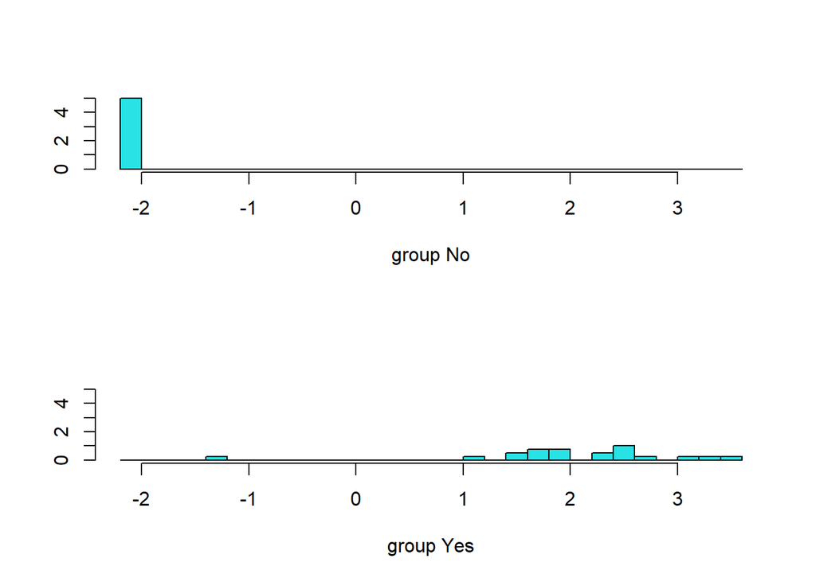

```r
plot(r)
```

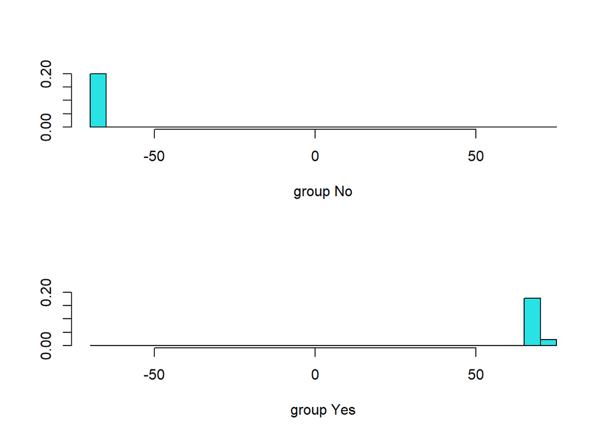

```r
plot(r3)
```

### Inference

- Here, we can see that all the observations are in one line and there is no overlap.

### Visualization for the training data

```r
training_sample <- sample(c(TRUE, FALSE), nrow(sociallda2), replace = T, prob = c(0.75,0.25))
train <- sociallda2[training_sample, ]
test <- sociallda2[!training_sample, ]
#lets run LDA like before
sociallda2[is.na(sociallda2)] <- mean(sociallda2, na.rm = TRUE)
```

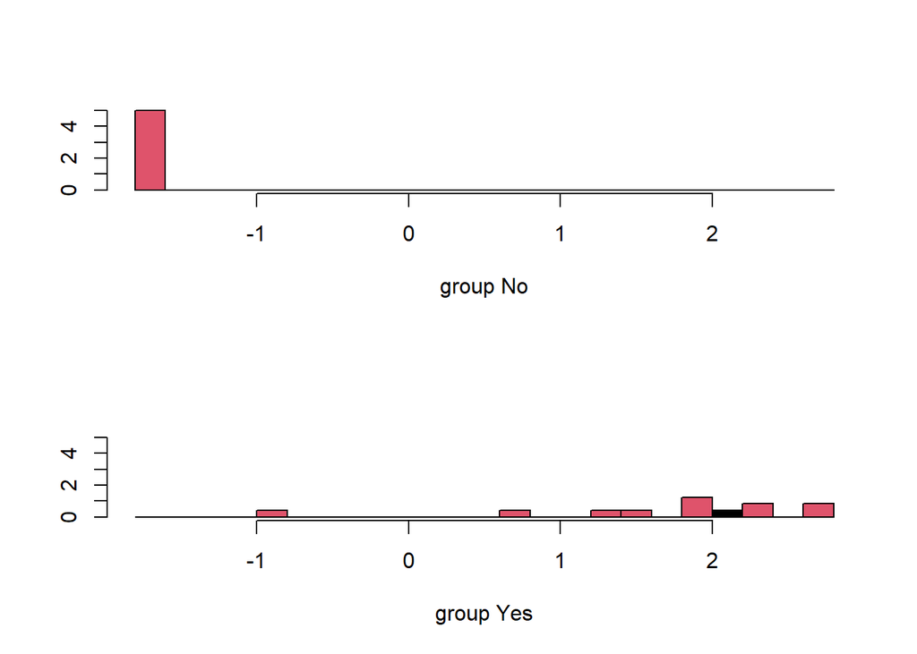

```r
lda.sociallda2 <- lda(Mood_Productivity ~ ., train)
# do a quick plot to understand how good the model is
plot(lda.sociallda2, col = as.integer(train$Mood_Productivity))
```

### Inference

- Here, we can see that all the observations are in one line and there is no overlap.

### Accuracy

```r
lda.train <- predict(lda.sociallda2)
train$lda <- lda.train$class
table(train$lda,train$Mood_Productivity)
```

```
##
##       No Yes
##   No   1   1
##   Yes  0  11
```